# Log Transformation

Kayla Johnson

October 27, 2020

```r
library(dplyr)
```

# Introduction

It is common in the analysis of biological data to log transform skewed data. We then must find the distribution of the new data, after it goes through the log transformation. Some statistical tests (such as t-tests and ANOVA tests) require that the data is normally distributed. For example, one may log transform concentrations of data representing dose response before running statistical tests.

# Assignment

In this assignment I will answer a series of questions related to the transformation of data. I will use both analytic methods and simulation to answer the questions

## Background

Some relevant concepts that will be explored are Distributions, the Probability Density Function, and the Cumulative Density Function.

### Distributions

In this assignment, we will be using the gamma distribution, the log normal distribution, and the continuous uniform distribution which are all continuous distributions.

**Gamma Distribution**

A *gamma distribution* is a right-skewed, continuous probability function. It is useful in cases where there is a minimum of zero.

**Log Normal Distribution**

A *log- normal distribution* is a continuous distribution of a random variable whose logarithm is *normally distributed*.

**Uniform Distribution**

A *continuous uniform distribution* is a continuous distribution in which all outcomes are equally likely

### Probability Density Function

The **probability density function** is a function defines the probability distribution (the likelihood of an outcome). When we graph the PDF we can find the area under the curve in an interval to find the probability that a discrete random variable occurs.

### Cumulative Distribution Function

The **cumulative density function** is a function that gives the probability that a random variable is less than or equal to the inputted variable of the function.

## Part 1

For each distribution below I will:

**1.** generate a figure of the PDF and CDF. The mean and median will also be marked in the figure.

**2.** generate a figure of the PDF and CDF of the transformation Y = log(X) random variable. I will mark the mean and median in the figure. I will use either simulation or analytic methods in order to find the PDF and CDF of the transformation.

**3.** generate 1000 samples of size 100. For each sample, I will calculate the geometric and arithmetic sample means. I will add a line of identity as a reference line.

**4.** generate a histogram of the difference between the arithmetic mean and the geometric mean.

### Gamma Distribution

*X* ∼ GAMMA(shape = 3, scale = 1)

Recall that: A *gamma distribution* is a right-skewed, continuous probability function. It is useful in cases where there is a minimum of zero.

1. Generate a figure of the PDF and CDF for the gamma distribution. Mark the medians and means in the figure.

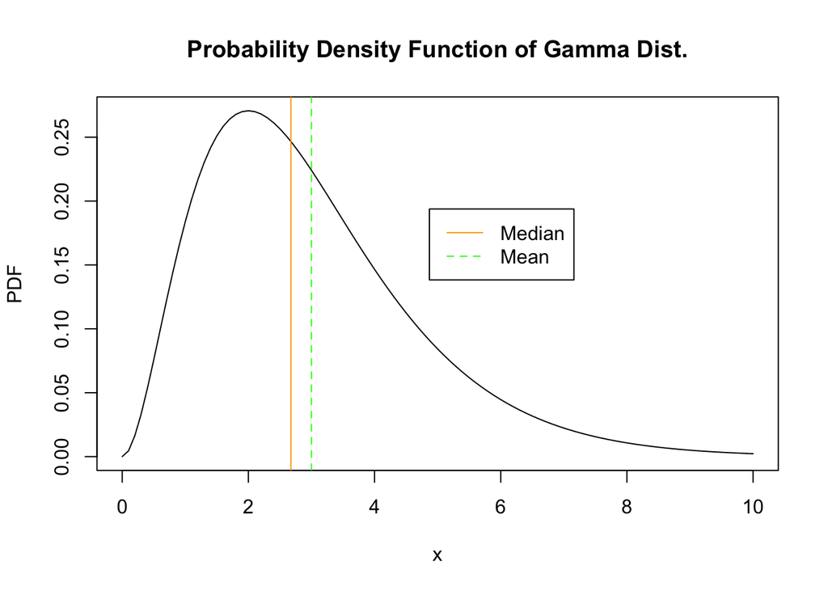

```r
# Generate a figure of the PDF and CDF.
# Mark the mean and median in the figure.
shap= 3
scal=1

# PDF
# For the PDF of a gamma distribution we use the function dgamma()
x= seq(0,10, by= 0.1)
pdf <- dgamma(x, shape= shap, scale= scal)

mean_gamma = shap*scal
median_gamma = qgamma(0.5, shape= shap, scale= scal)

plot(x, pdf, type = "l", main= "Probability Density Function of Gamma Dist.", ylab= "PDF")
mean_line= abline(v= mean_gamma, col="green", lty= 2)
median_line= abline(v= median_gamma, col= "orange")
legend("topright", inset= 0.3, legend=c("Median", "Mean"), col=c("orange","green"), lty= 1:2, cex= 1)
```

The parameters for a gamma distribution are shape and scale. To find the PDF of the of the gamma distribution, I was able to use the function **dgamma()**. The probability density function of the gamma distribution gives us the likelihood of each outcome. The mean value in the sequence from 0 to 10 is 3, and the median value is 2.67406. This makes sense, since the curve is right skewed and very little area is above the values between 6 and 10.

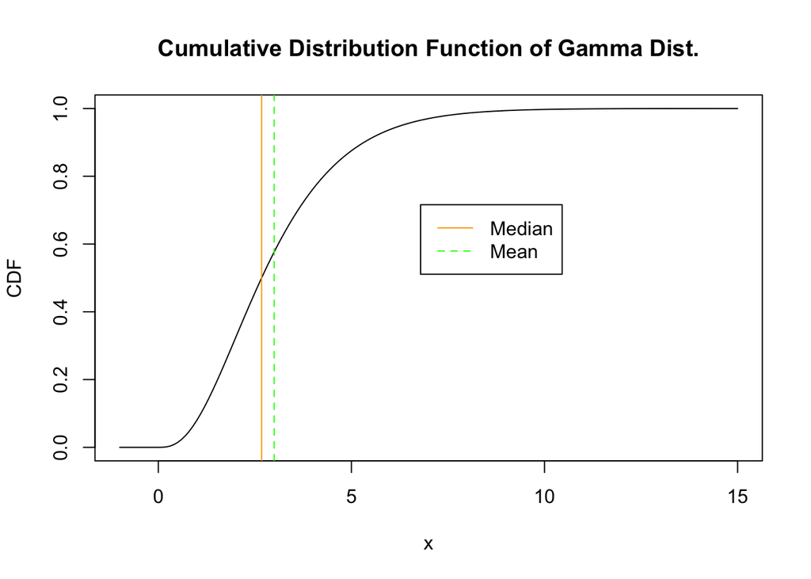

```r
# CDF
# For the CDF of the gamma distribution we use the function pgamma()
x= seq(-1,15, by= 0.1)
cdf <- pgamma(x, shape=shap, scale=scal)

plot(x, cdf, type = "l", main= "Cumulative Distribution Function of Gamma Dist.", ylab = "CDF" )
mean_line= abline(v= mean_gamma, col="green", lty= 2)
median_line= abline(v= median_gamma, col= "orange")
legend("topright", inset= 0.3, legend=c("Median", "Mean"), col=c("orange","green"), lty= 1:2, cex= 1)
```

I was able to use the function **pgamma()** to find the CDF of the gamma distribution. The cumulative density function for the gamma distribution gives the probability that a random variable is less than or equal to the inputted variable of the function. From the graph we can see that there is a high probability that the random variable is less than or equal to the independent variable when the independent variable is 5. This connects to the graph of the PDF which had very little area under the curve from the values 6 to 10.

2. Generate a figure of the PDF and CDF of the transformation Y = log(X) random variable. Mark the median and mean in the figure.

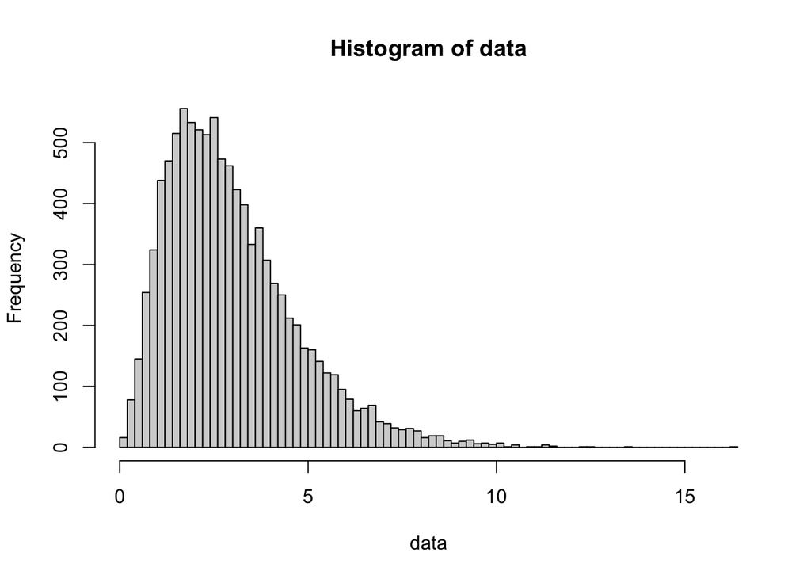

```r
# Log transform the data
# Data for 10000 hospital patients
data <- rgamma(10000, shape= 3, scale = 1)
hist(data, breaks = 100)
```

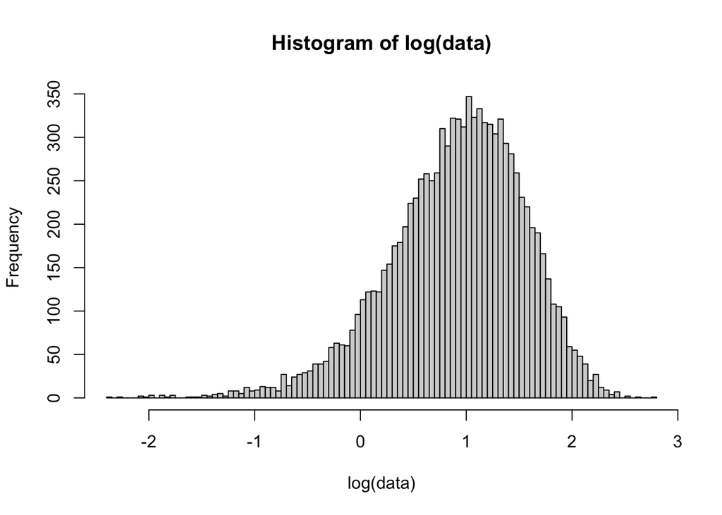

```r
hist(log(data), breaks = 100)
```

```r
#Below is a plot of the ecdf
#plot(ecdf(data))
#curve(pgamma(x, shape=3, scale=1), col= "red", add= TRUE)
#empirical cumulative density function
#used pgamma() for CDF
# CDF is the actual probability function that spits out the probabilities
```

The histograms above shows the impact of the log transformation on gamma distributed data. At first, our data is right skewed, however log transforming it causes it to be left skewed.

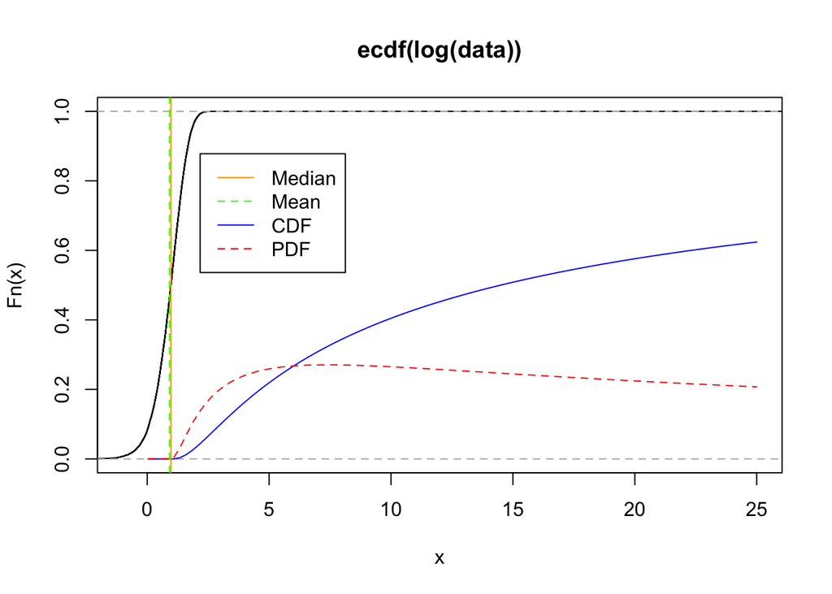

```r
# Generate a figure of the PDF and CDF of the transformation Y = log(X) random variable. Mark the median and mean in the figure.
plot(ecdf(log(data)), xlim= c(-1, 25))
curve(pgamma(log(x), shape=3, scale=1), col= "blue", add= TRUE)
curve(dgamma(log(x), shape=3, scale=1), col= "red", add= TRUE, lty= 2)
mean_logdata= mean(log(data))
median_logdata= median(log(data))
meanlog_line= abline(v= mean_logdata, col="green", lty= 2)
medianlog_line= abline(v= median_logdata, col= "orange")
legend("topleft", inset= 0.15, legend=c("Median", "Mean", "CDF", "PDF"), col=c("orange","green", "blue", "red"), lty= 1:2, cex= 1)
```

We can also find the PDF and the CDF for the log transformed data. As we can see from the graph above, the mean of the log transformed values is 0.9134371 and the median is 0.9749225. The CDF does not reach a 1.0 probability in the graph, so I can see that there are values in the data that are not represented on the graph. The PDF shows that there is a great likelihood that an outcome has a value around 5.

3. Generate 1000 samples of size 100. For each sample, calculate the geometric and arithmetic sample means. Add a line of identity as a reference line.

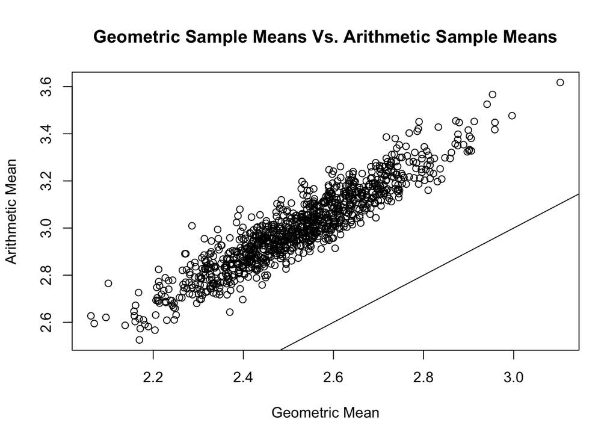

```r
# rgamma generates a vector of gamma distributed random values
arith_mean= NA
geom_mean= NA
diff_mean= NA

for(i in 1:1000){
  data= rgamma(n=100, shape= shap, scale= scal)
  arith_mean[i]= mean(data)
  geom_mean[i]= exp(mean(log(data)))
  diff_mean[i]= arith_mean[i]-geom_mean[i]
}


plot(geom_mean, arith_mean, main= "Geometric Sample Means Vs. Arithmetic Sample Means", xlab= "Geometric Mean", ylab= "Arithmetic Mean")
abline(0,1)
```

```r
# Can see that the arithmetic means are greater than the corresponding geometric means
```

I used the function **rgamma()** to generate a sample of size 100 and created a simulation that goes through 1000 iterations. The important values that we are calculating are the arithmetic means and the geometric means. I also calculated the differences between the arithmetic and geometric means. This value will be used in the next question. To find the arithmetic mean, we just find the mean of the data. To find the geometric mean, we find the mean of the logged data and then use then compute the exponential function with the value. The plot above shows that the values for arithmetic mean are higher than the values for the geometric mean.

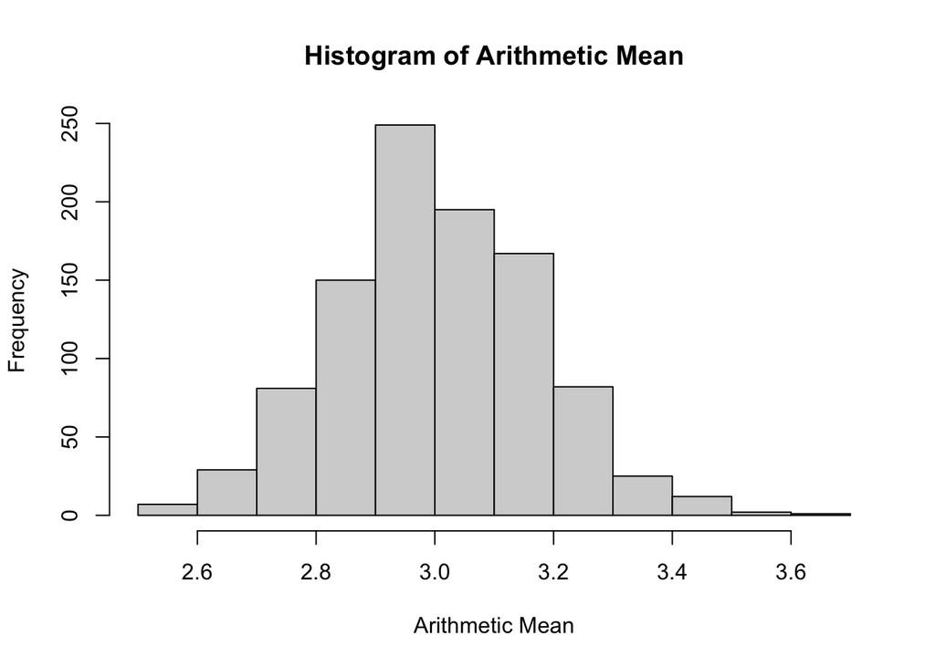

```r
# When we compare the histograms for the arithmetic means and geometric means we can see that the shapes of the histograms are similar, but the histogram for arithmetic mean has higher values than the histogram for geometric mean.

hist(arith_mean, main= "Histogram of Arithmetic Mean", xlab= "Arithmetic Mean")
```

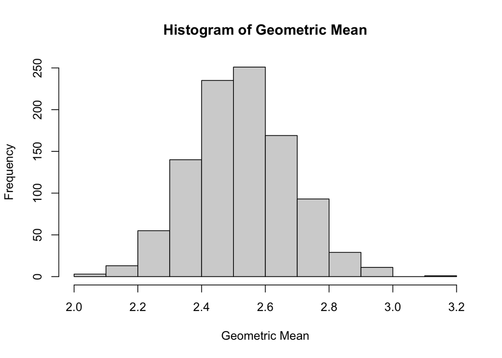

```r
hist(geom_mean, main= "Histogram of Geometric Mean", xlab= "Geometric Mean")
```

The histograms above further show that the values for the arithmetic means are higher than the values for the geometric means. We also can note that both histograms have a similar shape.

4. Generate a histogram of the difference between the arithmetic mean and the geometric mean.

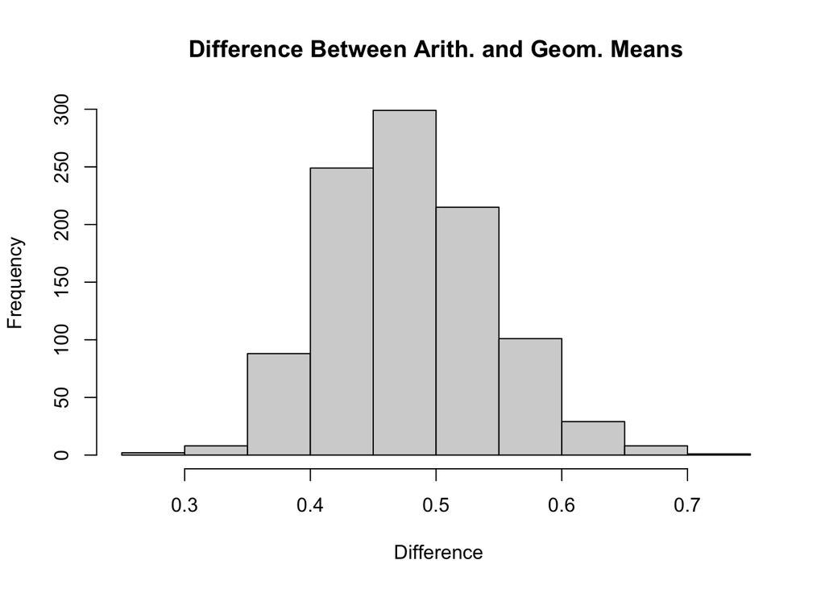

```r
# Subtracted the geometric mean from the arithmetic mean, since the arithmetic mean is greater

hist(diff_mean, main= "Difference Between Arith. and Geom. Means", xlab= " Difference")
```

To find the difference between the means, I subtracted the geometric mean from the arithmetic mean since the arithmetic mean is greater. We can see that there are not large differences between the two means.

### Log Normal Distribution

*X* ∼ LOG NORMAL(*μ* = − 1, *σ* = 1)

Recall that: A *log- normal distribution* is a continuous distribution of a random variable whose logarithm is *normally distributed*.

1. Generate a figure of the PDF and CDF for the log normal distribution. Mark the medians and means in the figure.

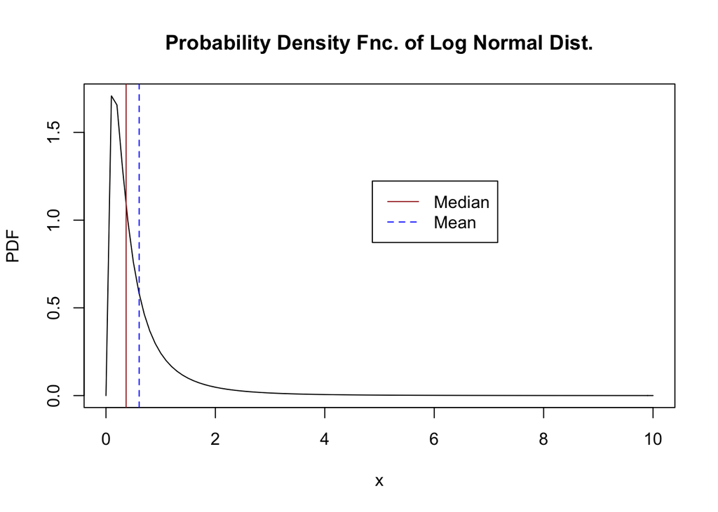

```r
# Generate a figure of the PDF and CDF.
# Mark the mean and median in the figure.
mean_ln = -1
sd_ln= 1

# PDF
# For the PDF of a log normal distribution we use the function dlnorm()
x= seq(0,10, by= 0.1)
pdf <- dlnorm(x, meanlog = mean_ln, sdlog = sd_ln)

mean_lognormal= exp((mean_ln)+((sd_ln^2)/2))
median_lognormal= qlnorm(0.5, meanlog= mean_ln, sdlog= sd_ln)

# Alternatively the formula for the median of the log normal distribution is:
# median = exp(mean_ln)

plot(x, pdf, type = "l", main= "Probability Density Fnc. of Log Normal Dist.", ylab= "PDF")
mean_line= abline(v= mean_lognormal, col="blue", lty= 2)
median_line= abline(v= median_lognormal, col= "brown")
legend("topright", inset= 0.3, legend=c("Median", "Mean"), col=c("brown","blue"), lty= 1:2, cex= 1)
```

The parameters for a log normal distribution are mean and standard deviation. To find the PDF of the of the log normal distribution, I was able to use the function **dlnorm()**. The probability density function of the log normal distribution gives us the likelihood of each outcome. The mean value in the sequence from 0 to 10 is 0.6065307, and the median value is 0.3678794. This makes sense, since the curve is right skewed and very little area is above the values between 2 and 10.

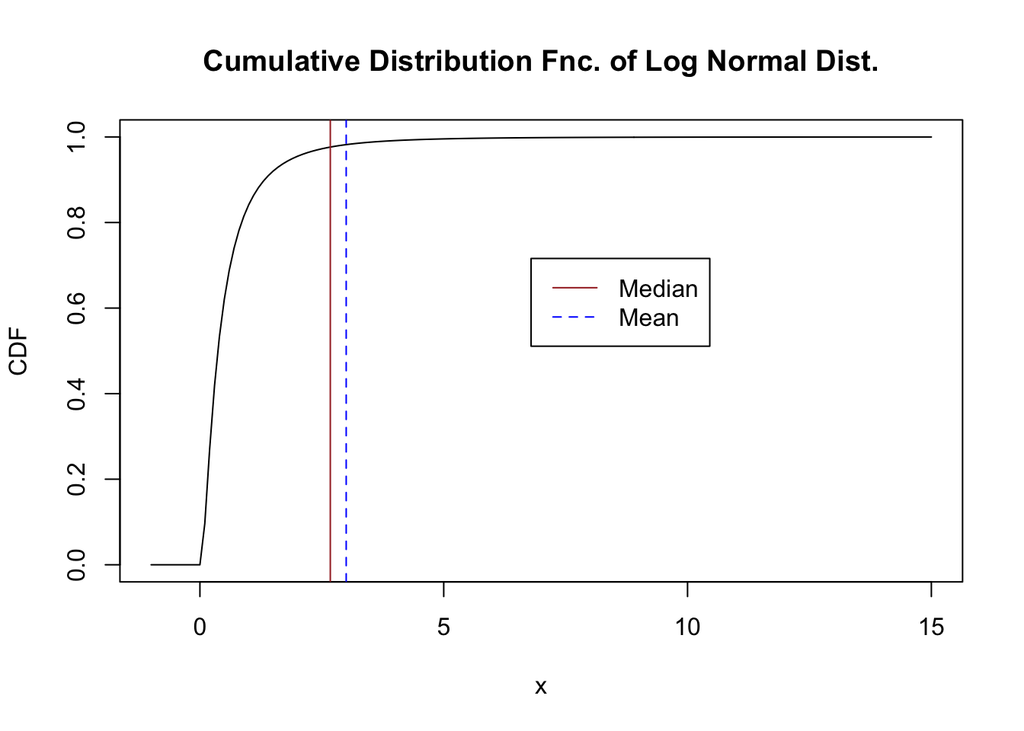

```r
# CDF
# For the CDF of the log normal distribution we use the function plnorm()
x= seq(-1,15, by= 0.1)
cdf <- plnorm(x, meanlog= mean_ln, sdlog= sd_ln)

plot(x, cdf, type = "l", main= "Cumulative Distribution Fnc. of Log Normal Dist.", ylab= "CDF")
mean_line= abline(v= mean_gamma, col="blue", lty= 2)
median_line= abline(v= median_gamma, col= "brown")
legend("topright", inset= 0.3, legend=c("Median", "Mean"), col=c("brown","blue"), lty= 1:2, cex= 1)
```

I was able to use the function **plnorm()** to find the CDF of the log normal distribution. The cumulative density function for the log normal distribution gives the probability that a random variable is less than or equal to the inputted variable of the function. From the graph we can see that there is a high probability that the random variable is less than or equal to the independent variable when the independent variable is 2. This connects to the graph of the PDF which had very little area under the curve from the values 2 to 10.

2. Generate a figure of the PDF and CDF of the transformation Y = log(X) random variable. Mark the median and mean in the figure.

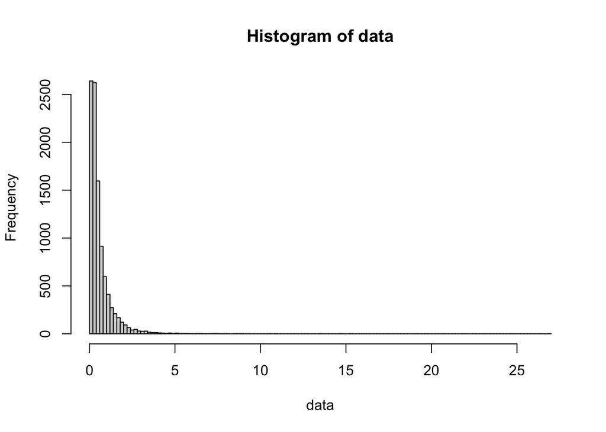

```r
# Log transform the data
# Data for 10000 hospital patients
data <- rlnorm(10000, meanlog = mean_ln, sdlog = sd_ln)
hist(data, breaks = 100)
```

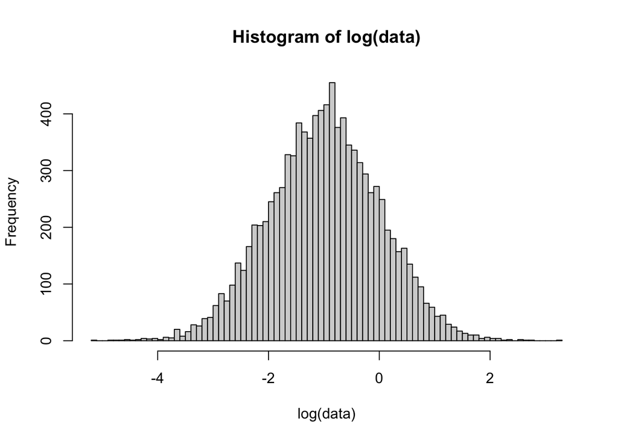

```r
hist(log(data), breaks = 100)
```

```r
#plot(ecdf(data))
#curve(plnorm(x, meanlog = mean_ln, sdlog = sd_ln), col= "red", add= TRUE)
#empirical cumulative density function
#used plnorm() for CDF
# CDF is the actual probability function that spits out the probabilities
```

The histograms above shows the impact of the log transformation on log normal distributed data. At first, our data is right skewed, however log transforming it causes it to be normally distributed.

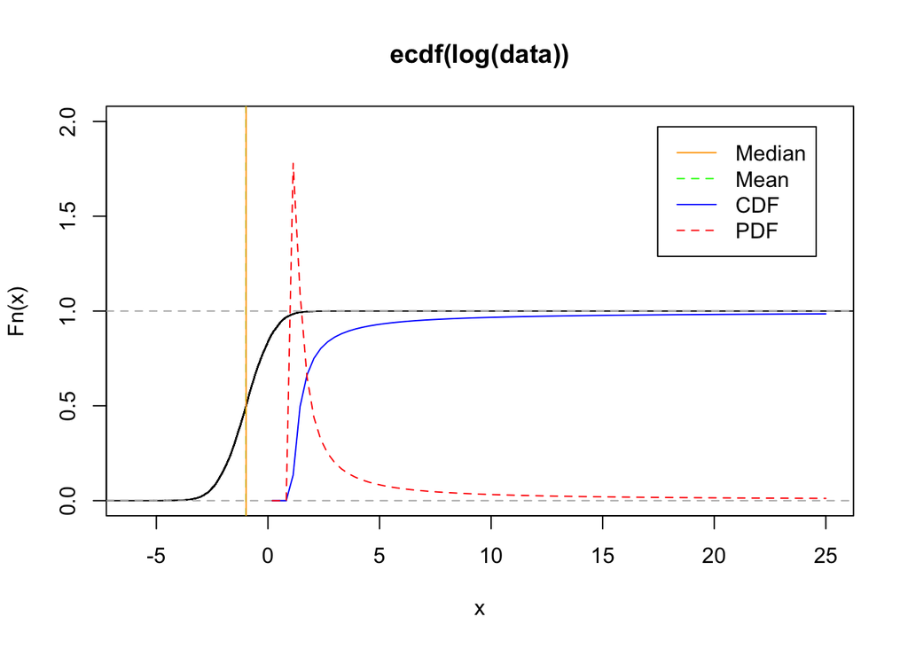

```r
plot(ecdf(log(data)), xlim= c(-6, 25), ylim= c(0, 2))
curve(plnorm(log(x), meanlog = mean_ln, sdlog = sd_ln), col= "blue", add= TRUE)
curve(dlnorm(log(x), meanlog = mean_ln, sdlog = sd_ln), col= "red", add= TRUE, lty= 2)
mean_logdata= mean(log(data))
median_logdata= median(log(data))
meanlog_line= abline(v= mean_logdata, col="green", lty= 2)
medianlog_line= abline(v= median_logdata, col= "orange")
legend("topright", inset= 0.05, legend=c("Median", "Mean", "CDF", "PDF"), col=c("orange","green", "blue", "red"), lty= 1:2, cex= 1)
```

We can also find the PDF and the CDF for the log transformed data. As we can see from the graph above, the mean of the log transformed values is -0.9929865 and the median is -0.9988561. The CDF reaches a 1.0 probability in the graph, so I can see that all of the values in the data are represented on the graph. The PDF shows that there is a great likelihood that an outcome has a value around 1.

3. Generate 1000 samples of size 100. For each sample, calculate the geometric and arithmetic sample means. Add a line of identity as a reference line.

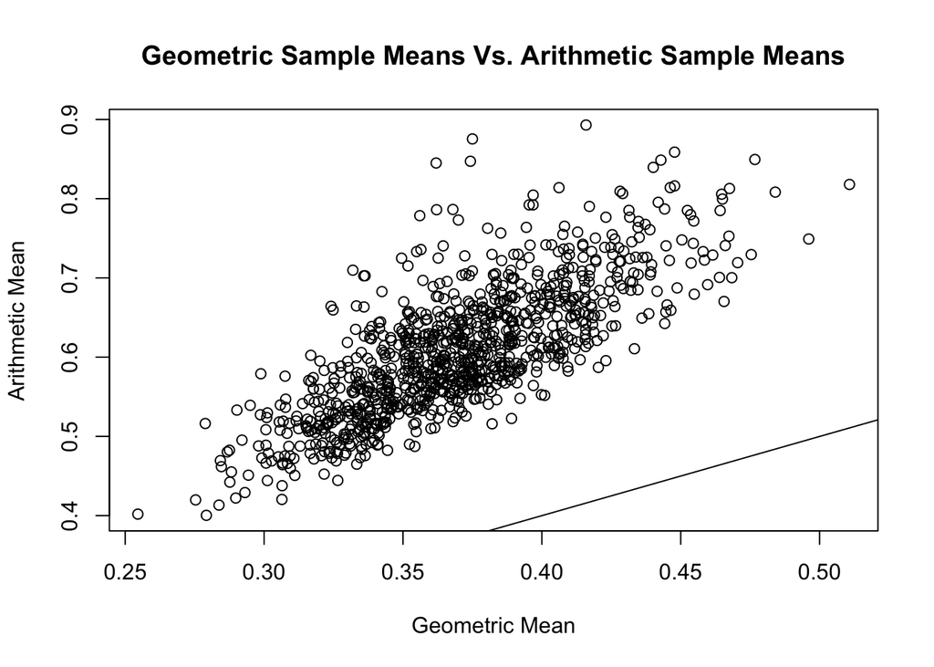

```r
# rlnorm generates a vector of gamma distributed random values
arith_mean= NA
geom_mean= NA
diff_mean= NA

for(i in 1:1000){
  data= rlnorm(n=100, meanlog = mean_ln, sdlog= sd_ln)
  arith_mean[i]= mean(data)
  geom_mean[i]= exp(mean(log(data)))
  diff_mean[i]= arith_mean[i]-geom_mean[i]
}

plot(geom_mean, arith_mean, main= "Geometric Sample Means Vs. Arithmetic Sample Means", xlab= "Geometric Mean", ylab= "Arithmetic Mean")
abline(0,1)
```

```r
# Can see that the arithmetic means are greater than the corresponding geometric means
```

I used the function **rlnorm()** to generate a sample of size 100 and created a simulation that goes through 1000 iterations. The important values that we are calculating are the arithmetic means and the geometric means. I also calculated the differences between the arithmetic and geometric means. This value will be used in the next question. To find the arithmetic mean, we just find the mean of the data. To find the geometric mean, we find the mean of the logged data and then use then compute the exponential function with the value. Similar to the plot from the gamma distribution, the plot above also shows that the values for arithmetic mean are higher than the values for the geometric mean.

4. Generate a histogram of the difference between the arithmetic mean and the geometric mean.

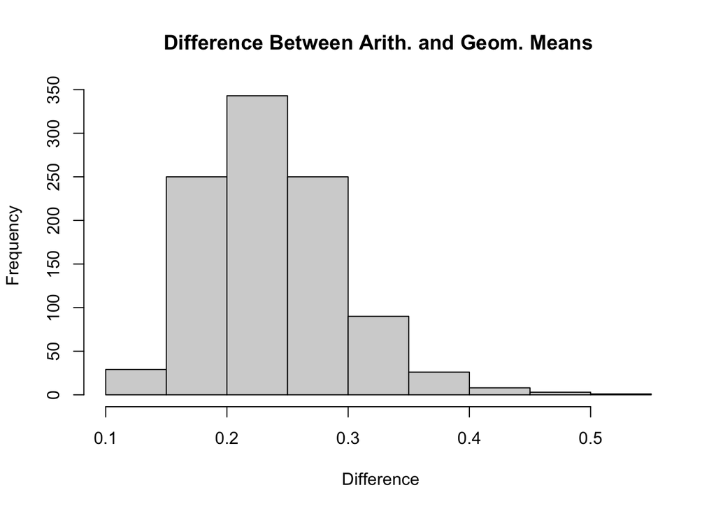

```r
# Subtracted the geometric mean from the arithmetic mean, since the arithmetic mean is greater

hist(diff_mean, main= "Difference Between Arith. and Geom. Means", xlab= " Difference")
```

### Uniform Distribution

*X* ∼ UNIFORM(0, 12)

Recall that: A *continuous uniform distribution* is a continuous distribution in which all outcomes are equally likely.

1. Generate a figure of the PDF and CDF for the uniform distribution. Mark the medians and means in the figure.

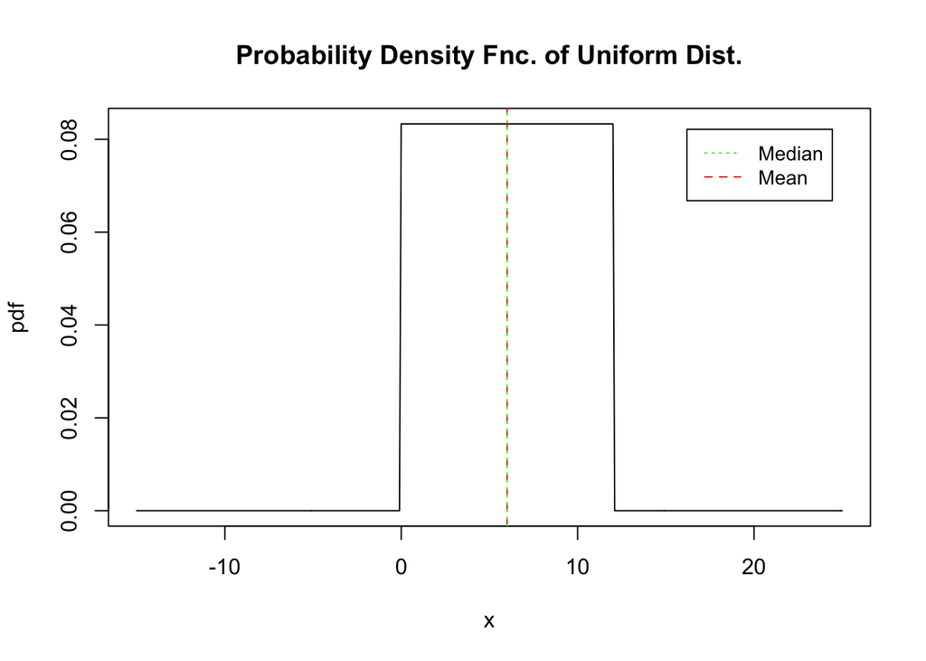

```r
# Generate a figure of the PDF and CDF.
# Mark the mean and median in the figure.
min_uni = 0
max_uni = 12

# PDF
# For the PDF of a uniform we use the function dunif()
x= seq(-15,25, by= .1)
pdf <- dunif(x, min = min_uni, max = max_uni)

# Mean and median should be the same in a uniform distribution
# The formula for both: 1/2 * (a + b)
mean_uni= (1/2)*(min_uni + max_uni)
median_uni= qunif(0.5, min = min_uni, max = max_uni)

plot(x, pdf, type = "l", main= "Probability Density Fnc. of Uniform Dist.")
mean_line= abline(v= mean_uni, col="red", lty= 2)
median_line= abline(v= median_uni, col= "green", lty= 3)
legend("topright", inset= 0.05, legend=c("Median", "Mean"), col=c("green","red"), lty= 3:2, cex= .9)
```

The parameters for a uniform distribution are minimum and maximum. To find the PDF of the of the uniform distribution, I was able to use the function **dunif()**. The probability density function of the uniform distribution gives us the likelihood of each outcome. The mean value in the sequence from 0 to 12 is 6, and the median value is also 6. It makes sense that the median and mean would be the same number, since each outcome is equally likely.

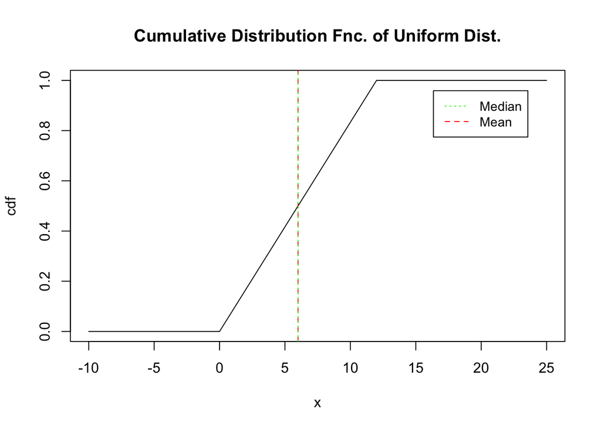

```r
# CDF
# For the CDF of the uniform distribution we use the function punif()
x= seq(-10,25, by= .1)
cdf <- punif(x, min = min_uni, max= max_uni)

plot(x, cdf, type = "l", main= "Cumulative Distribution Fnc. of Uniform Dist.")
mean_line= abline(v= mean_uni, col="red", lty= 2)
median_line= abline(v= median_uni, col= "green", lty= 3)
legend("topright", inset= 0.075, legend=c("Median", "Mean"), col=c("green","red"), lty= 3:2, cex= .9)
```

I was able to use the function **punif()** to find the CDF of the uniform distribution. The cumulative density function for the uniform distribution gives the probability that a random variable is less than or equal to the inputted variable of the function. From the graph we can see that there is 1.0 probability that a random variable is less than or equal to 12. This makes sense, since the sequence is from 0 to 12.

2. Generate a figure of the PDF and CDF of the transformation Y = log(X) random variable. Mark the median and mean in the figure.

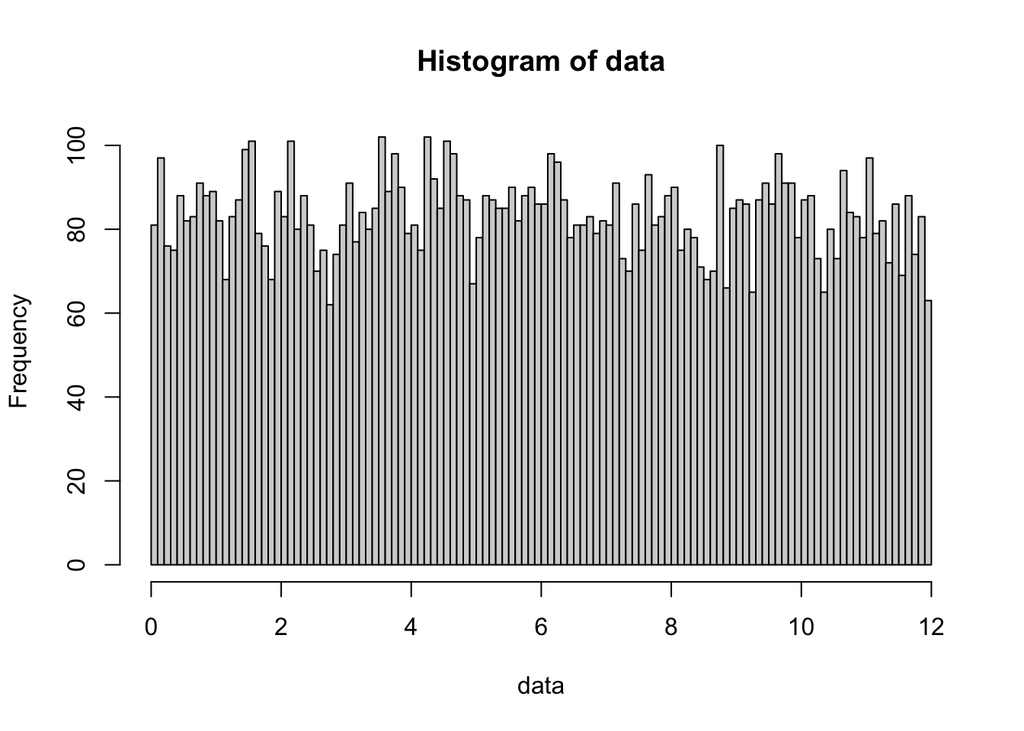

```r
# Log transform the data
# Data for 10000 hospital patients
data <- runif(10000, min= min_uni, max= max_uni)
hist(data, breaks = 100)
```

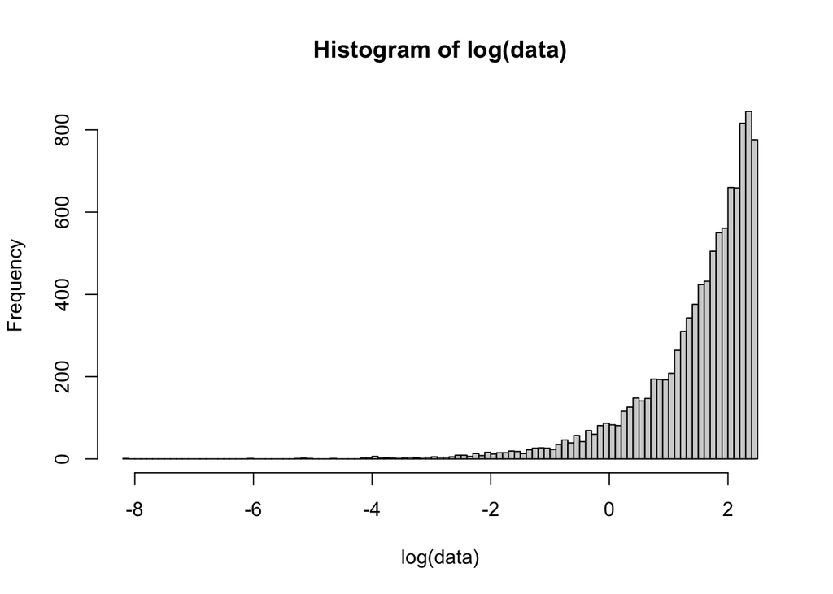

```r
hist(log(data), breaks = 100)
```

```r
#plot(ecdf(data))
#curve(punif(x, min= min_uni, max= max_uni), col= "red", add= TRUE)
#empirical cumulative density function
#used punif() for CDF
# CDF is the actual probability function that spits out the probabilities
```

The histograms above shows the impact of the log transformation on uniform distributed data. At first, there is not much variance in our data, however log transforming it causes it to be left skewed.

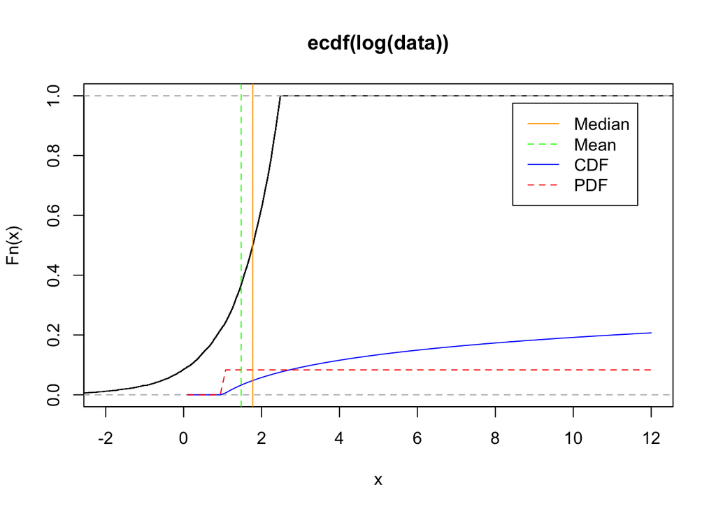

```r
plot(ecdf(log(data)), xlim= c(-2, 12), ylim= c(0, 1))
curve(punif(log(x), min= min_uni, max= max_uni), col= "blue", add= TRUE)
curve(dunif(log(x), min= min_uni, max= max_uni), col= "red", add= TRUE, lty= 2)
mean_logdata= mean(log(data))
median_logdata= median(log(data))
meanlog_line= abline(v= mean_logdata, col="green", lty= 2)
medianlog_line= abline(v= median_logdata, col= "orange")
legend("topright", inset= 0.06, legend=c("Median", "Mean", "CDF", "PDF"), col=c("orange","green", "blue", "red"), lty= 1:2, cex= 1)
```

We can also find the PDF and the CDF for the log transformed data. As we can see from the graph above, the mean of the log transformed values is 1.487848 and the median is 1.791316. The CDF does not reach a 1.0 probability in the graph, so I can see that there are values in the data that are not represented on the graph. The PDF shows that there is a an equal likelihood for each outcome.

3. Generate 1000 samples of size 100. For each sample, calculate the geometric and arithmetic sample means. Add a line of identity as a reference line.

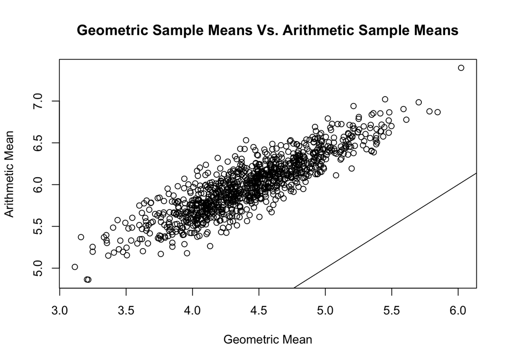

```r
# rlnorm generates a vector of gamma distributed random values
arith_mean= NA
geom_mean= NA
diff_mean= NA

for(i in 1:1000){
  data= runif(n=100, min= min_uni, max= max_uni)
  arith_mean[i]= mean(data)
  geom_mean[i]= exp(mean(log(data)))
  diff_mean[i]= arith_mean[i]-geom_mean[i]
}

plot(geom_mean, arith_mean, main= "Geometric Sample Means Vs. Arithmetic Sample Means", xlab= "Geometric Mean", ylab= "Arithmetic Mean")
abline(0,1)
```

```r
# Can see that the arithmetic means are greater than the corresponding geometric means
```

I used the function **runif()** to generate a sample of size 100 and created a simulation that goes through 1000 iterations. The important values that we are calculating are the arithmetic means and the geometric means. I also calculated the differences between the arithmetic and geometric means. This value will be used in the next question. To find the arithmetic mean, we just find the mean of the data. To find the geometric mean, we find the mean of the logged data and then use then compute the exponential function with the value. The plot above shows that the values for arithmetic mean are higher than the values for the geometric mean.

4. Generate a histogram of the difference between the arithmetic mean and the geometric mean.

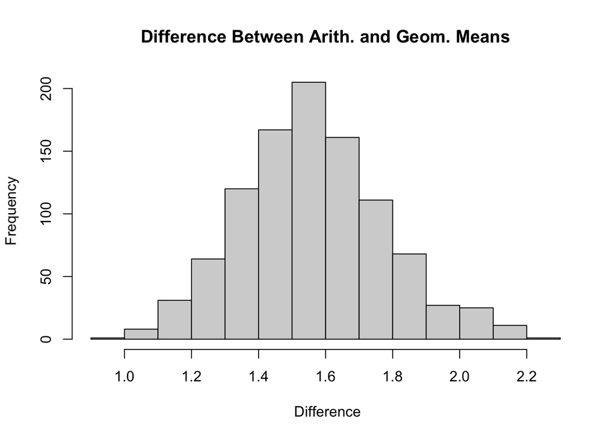

```r
# Subtracted the geometric mean from the arithmetic mean, since the arithmetic mean is greater

hist(diff_mean, main= "Difference Between Arith. and Geom. Means", xlab= " Difference")
```

## Part 2

Show that if *X*<sub>*i*</sub> > 0 for all *i*, then the arithmetic mean is greater than or equal to the geometric mean.

Hint: I will start with the sample mean of the transformation *Y*<sub>*i*</sub> = log (*X*<sub>*i*</sub>).

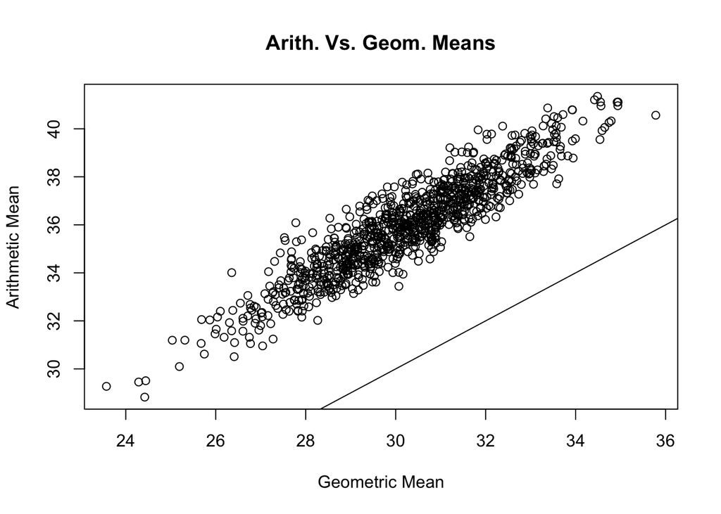

```r
require(magrittr)
R <- 1000
N <- 100
D <- rgamma(R*N, shape= 3, scale= 12) %>%
  array(dim= c(R,N))

E <- array(rgamma(R*N, shape= 3, scale= 12))
# rowMeans(D)
# arithmetic mean
ma <- apply(D, 1, function(x){mean(x)})
# geometric mean is the exponential of the mean
mg <- apply(D, 1, function(x){exp(mean(log(x)))})


# showing that the arithmetic mean is always larger than the geometric mean
plot(mg, ma, xlab= "Geometric Mean", ylab= "Arithmetic Mean", main= "Arith. Vs. Geom. Means")
abline(0,1)
```

When we plotted the arithmetic and geometric means for all three of the distributions, we noticed that the arithmetic means were higher than the geometric means. This is because the formulas are quite different. To find the arithmetic mean, we find take the mean of the data. However, to find the geometric mean we take the mean of log transformed data and then use the exponential function on those values.

## Part 3

I will answer the question: What is the correct relationship between *E*[log(*X*)] and log(*E*[*X*])? Is one always larger? Equal?

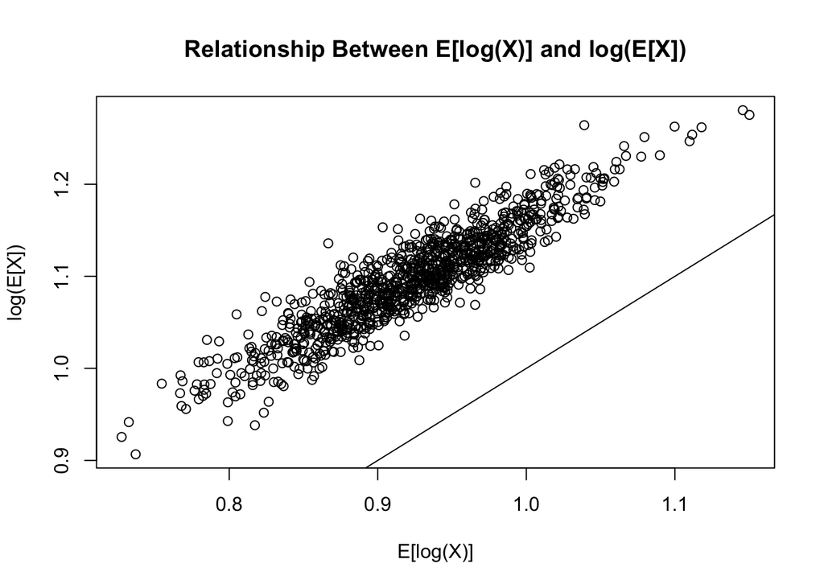

```r
# Expected value of the log of the random sample vs the log of the expected value of the random sample
expected_value_log= NA
log_expected_value= NA

for(i in 1:1000){
  data= rgamma(n=100, shape= shap, scale= scal)
  expected_value_log[i]= mean(log(data))
  log_expected_value[i]= log(mean(data))
}

plot(expected_value_log, log_expected_value, main= "Relationship Between E[log(X)] and log(E[X])", ylab= "log(E[X])", xlab= "E[log(X)]" )
abline(0,1)
```

# Conclusion

I hope that you found this process as helpful as I did. Going through this deliverable has given me a greater understanding of **distributions**, the **PDF**, and the **CDF**. It was interesting to visualize gamma, log normal, and uniform distributions. I also enjoyed seeing how log transformations impacted the distribution of the data. I now understand the importance of transforming data!I hope that my skills have impressed you, and I look forward to working with you in the future.